# cesus income usa

Fecha de publicación

18 de junio de 2026

## PREPARACION PARA LA CARGA DE DATOS:

Instalamos los paquetes que vamos a utilizar:

```r
# Instalamos pacman si no está disponible para gestionar paquetes
if (!require("pacman")) install.packages("pacman")
# Cargamos todas las librerías requeridas para la sesión
pacman::p_load(
  tidyverse,        # Manipulación de datos (dplyr, tidyr) y visualización (ggplot2)
  here,             # Manejo de rutas de archivos
  caret,            # Herramientas para partición de datos (train/test split)
  scales,           # Formateo de ejes y etiquetas en gráficos (porcentajes, comas)
  broom,            # Convertir outputs de modelos en dataframes (tidy, glance, augment)
  modelsummary,     # Creación de tablas de regresión estilo publicación académica
  kableExtra,       # decoración de tablas kable
  marginaleffects,  # Cálculo de efectos marginales y predicciones
  yardstick,        # Métricas de evaluación de clasificación (ROC, AUC, Matriz de Confusión)
  patchwork         # Organizar el apilado y composición de figuras
)
```

```r
#Cargamos nuestros datos con la libreria here.

base <- read_csv(here("TP3", "data", "adult_census_USA.csv"))
```

## LIMPIEZA DE VARIABLES

Primero nos encargamos de volver binaria la variable de income, para luego poder correr bien nuestros modelos.

```r
#Modificamos la variable de income para que sea mas facil para predecir.
base <- base %>% mutate (
  income_bin = ifelse (income == ">50K", 1, 0))
```

Ahora hacemos la seleccion de las variables que vamos a utilizar para predecir nuestros modelos. Las que vamos a elegir son las siguientes: age, education_num, hours_per_week, marital_status e income.

```r
base_mod <- base %>% select (income, income_bin, age, sex, education_num, occupation, hours_per_week, marital_status)
```

Sin embargo, como el criterio fundamental para decidir si debemos aplicar una transformación a los datos o incluir un término de interacción **no es correr modelos a ciegas**, sino **ver la distribución de los datos vamos a** miramos la distribucion de las variables para saber como conviene modificarlas para nuestro estudio:

```r
table (base_mod$age)
```

```
 17  18  19  20  21  22  23  24  25  26  27  28  29  30  31  32  33  34  35  36
120 158 225 206 226 252 327 307 336 328 337 346 361 405 408 398 430 443 414 462
 37  38  39  40  41  42  43  44  45  46  47  48  49  50  51  52  53  54  55  56
494 458 433 455 425 440 455 430 435 465 447 328 331 385 365 278 281 260 221 186
 57  58  59  60  61  62  63  64  65  66  67  68  69  70  71  72  73  74  75  76
201 210 199 161 144 111  89  87  65  63  65  49  36  31  27  23  25  19  16  11
 77  78  79  80  81  82  83  84  85  86  88  90
  8  10  11   9   6   5   2   2   1   1   2  16
```

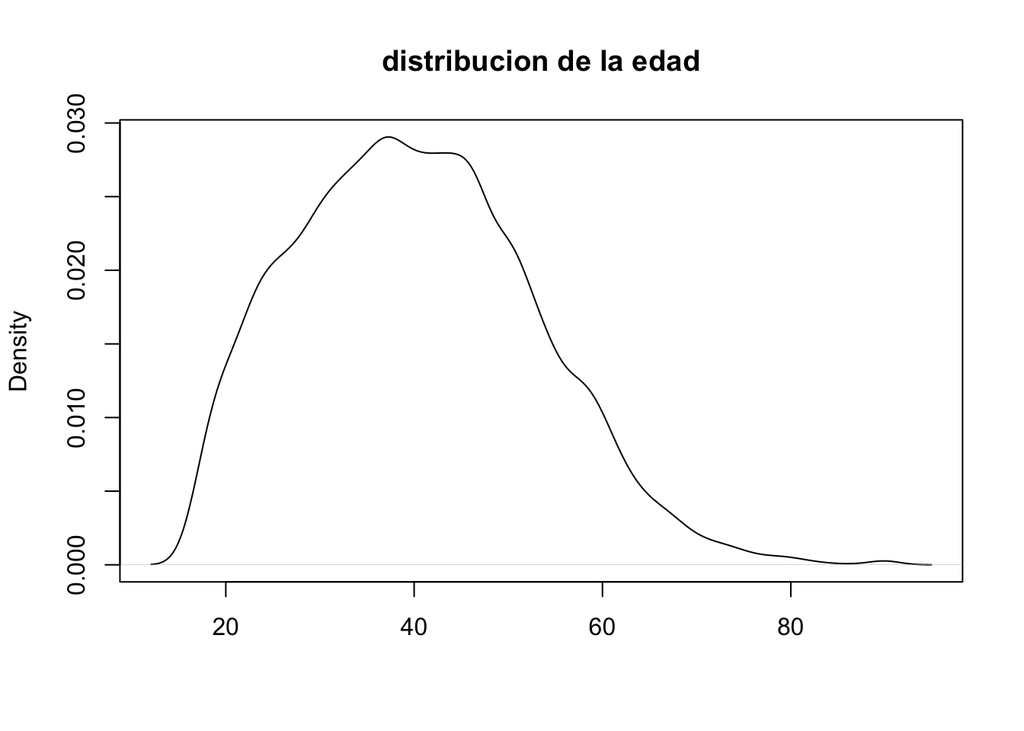

```r
base_mod$age%>%
  density(na.rm = TRUE) %>%
  plot (.,
        main = "distribucion de la edad",
        xlab = " ")
```

```r
table (base_mod$education_num)
```

```
   1    2    3    4    5    6    7    8    9   10   11   12   13   14   15   16
  16   56  120  240  182  320  418  153 4642 3231  686  555 3184 1194  451  318
```

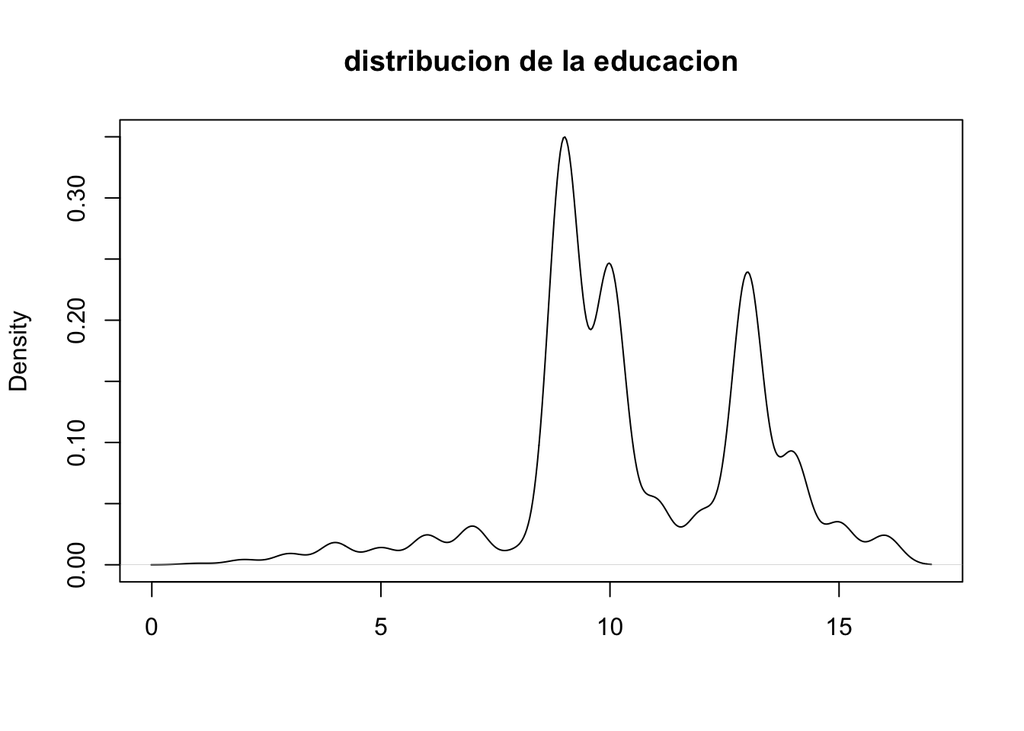

```r
base_mod$education_num%>%
  density(na.rm = TRUE) %>%
  plot (.,
        main = "distribucion de la educacion",
        xlab = " ")
```

```r
table (base_mod$hours_per_week)
```

```
   1    2    3    4    5    6    7    8    9   10   11   12   13   14   15   16
   1    7    7    9   17   13   10   31    5   84    5   49    4    7  119   75
  17   18   19   20   21   22   23   24   25   26   27   28   29   30   31   32
  11   23    2  427    8   18    7   89  224   16    5   27    1  417    1   98
  33   34   35   36   37   38   39   40   41   42   43   44   45   46   47   48
  12   12  556  102   62  217   20 7188   15  120   80  113 1090   48   30  284
  49   50   51   52   53   54   55   56   57   58   59   60   61   62   63   64
  14 1784    6   81   11   19  449   55   11   19    3  917    2    7    6   10
  65   66   67   68   70   72   73   74   75   76   77   78   80   81   84   85
 154    6    4    8  166   37    1    1   32    3    3    5   73    2   25    9
  86   87   88   89   90   91   92   95   96   97   98   99
   2    1    1    2   16    1    1    1    2    1    8   41
```

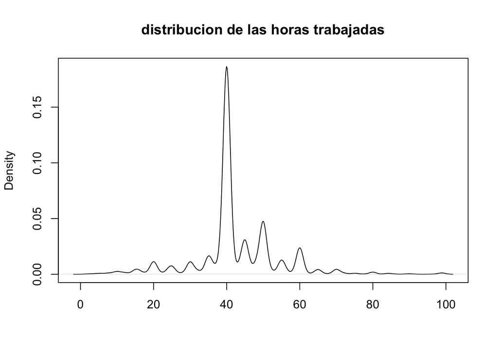

```r
base_mod$hours_per_week%>%
  density(na.rm = TRUE) %>%
  plot (.,
        main = "distribucion de las horas trabajadas",
        xlab = " ")
```

```r
table (base_mod$marital_status)
```

```
             Divorced     Married-AF-spouse    Married-civ-spouse
                 1801                    16                  9184
Married-spouse-absent         Never-married             Separated
                  141                  3877                   388
              Widowed
                  359
```

Entonces, una vez que observamos la distribucion de los datos, lo primero que cambiamos es la variable de married ya que creemos que es conveniente hacerlo.

```r
#Modificamos las horas trabajadas transformandolo en variables binarias

base_mod <- base_mod %>%
  mutate(

    married = ifelse(marital_status %in%
                       c("Married-civ-spouse",
                         "Married-AF-spouse"), 1,

                     ifelse(marital_status %in%
                              c("Never-married",
                                "Divorced",
                                "Separated",
                                "Widowed",
                                "Married-spouse-absent"), 0, NA)),

    never_married = ifelse(marital_status == "Never-married", 1,

                           ifelse(marital_status %in%
                                    c("Married-civ-spouse",
                                      "Married-AF-spouse",
                                      "Divorced",
                                      "Separated",
                                      "Widowed",
                                      "Married-spouse-absent"), 0, NA)),

    div_sep = ifelse(marital_status %in%
                       c("Divorced",
                         "Separated"), 1,

                     ifelse(marital_status %in%
                              c("Married-civ-spouse",
                                "Married-AF-spouse",
                                "Never-married",
                                "Widowed",
                                "Married-spouse-absent"), 0, NA)),

    widowed_other = ifelse(marital_status %in%
                             c("Widowed",
                               "Married-spouse-absent"), 1,

                           ifelse(marital_status %in%
                                    c("Married-civ-spouse",
                                      "Married-AF-spouse",
                                      "Never-married",
                                      "Divorced",
                                      "Separated"), 0, NA))
  )
```

## BALANCE DE DATOS:

Una vez que tenemos todos los datos mas ordenados y limpios, nos fijamos si estan balanceados

```r
# Comprobamos el balance de nuestra variable objetivo
message("Distribución de la variable objetivo (income_bin):")
```

```
Distribución de la variable objetivo (income_bin):
```

```r
print(table(base_mod$income_bin))
```

```
   0    1
8258 7508
```

```r
message("Proporciones:")
```

```
Proporciones:
```

```r
print(prop.table(table(base_mod$income_bin)) |> round(3))
```

```
    0     1
0.524 0.476
```

De esta forma, podemos observar que nuestros datos se encuentran balanceados ya que la variable objetivo, income_bin, cuenta con 52% de las observaciones que pertenencen a la categoria de ingresos bajos, mientras que hay un 47% que pertenecen a personas con ingresos altos o superiores a USD50k. Por lo tanto, solo enocontramos una diferencia de 4 puntos porcentuales entre ambas categorias.

## VISUALIZACIONES BIVARIADAS:

```r
# Paleta de colores para income_binaria
paleta_income <- c("0" = "#4e79a7", "1" = "#f28e2b")
```

Entonces, como hicimos con la variable de “married”, tambien vamos a observar como se distribuyen las variables de edad, horas trabajadas y nivel de educacion para analizar si es necesario modificar las mismas para analizarlas.

#### DISTRIBUCION DE EDAD VS INCOME

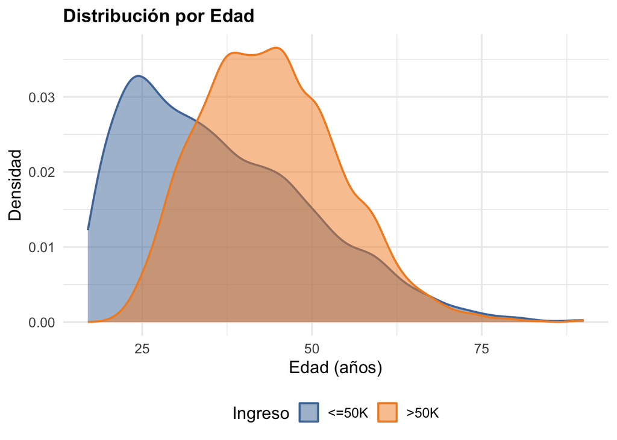

```r
# Edad vs Income (Density Plot)
plot_age <- base_mod |>
  ggplot(aes(x = age, fill = factor(income_bin), color = factor(income_bin))) +
  geom_density(alpha = 0.5, linewidth = 0.8) +
  scale_fill_manual(values = paleta_income, name = "Ingreso",
                    labels = c("0" = "<=50K", "1" = ">50K")) +
  scale_color_manual(values = paleta_income, name = "Ingreso",
                     labels = c("0" = "<=50K", "1" = ">50K")) +
  labs(
    title = "Distribución por Edad",
    x     = "Edad (años)",
    y     = "Densidad"
  ) +
  theme_minimal(base_size = 14) +
  theme(
    plot.title      = element_text(face = "bold", size = 15),
    legend.position = "bottom"
  )

print (plot_age)
```

#### DISTRIBUCION DE HORAS TRABAJADAS POR SEMANA VS INCOME

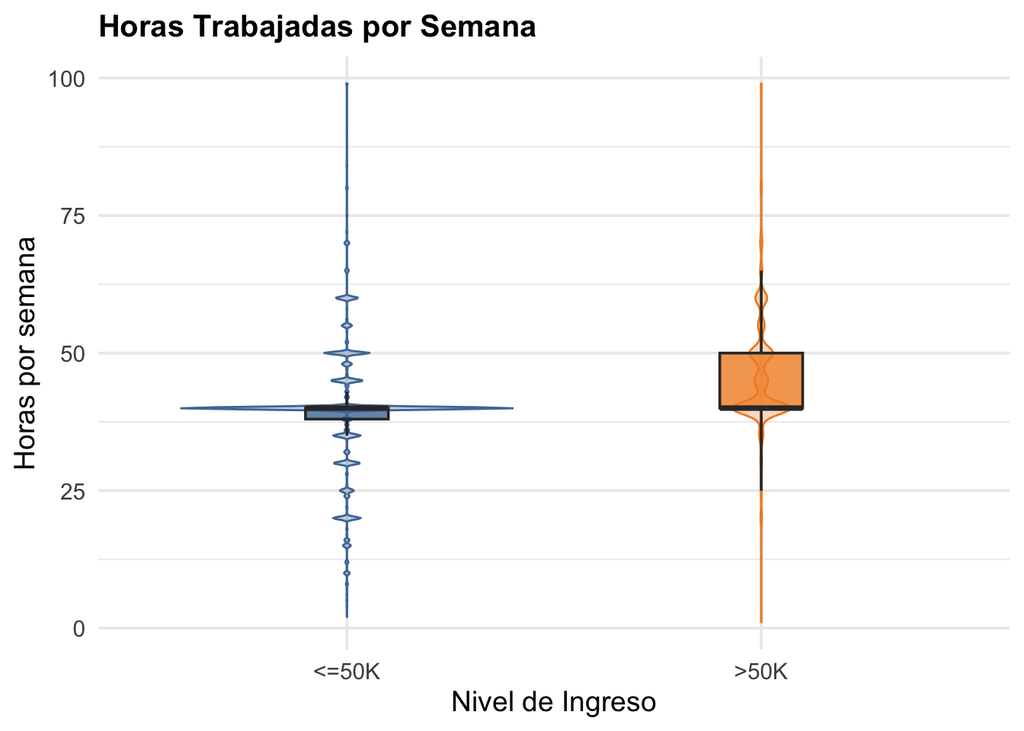

```r
# Horas por semana vs Income (Violin + Boxplot)
plot_hours <- base_mod |>
  ggplot(aes(x = factor(income_bin), y = hours_per_week,
             fill = factor(income_bin), color = factor(income_bin))) +
  geom_violin(alpha = 0.3, linewidth = 0.5, width = 0.8) +
  geom_boxplot(width = 0.2, alpha = 0.8, color = "gray20", outlier.shape = NA) +
  scale_fill_manual(values = paleta_income, guide = "none") +
  scale_color_manual(values = paleta_income, guide = "none") +
  scale_x_discrete(labels = c("0" = "<=50K", "1" = ">50K")) +
  labs(
    title = "Horas Trabajadas por Semana",
    x     = "Nivel de Ingreso",
    y     = "Horas por semana"
  ) +
  theme_minimal(base_size = 14) +
  theme(plot.title = element_text(face = "bold", size = 15))

print (plot_hours)
```

#### NIVEL DE EDUCACION VS INCOME

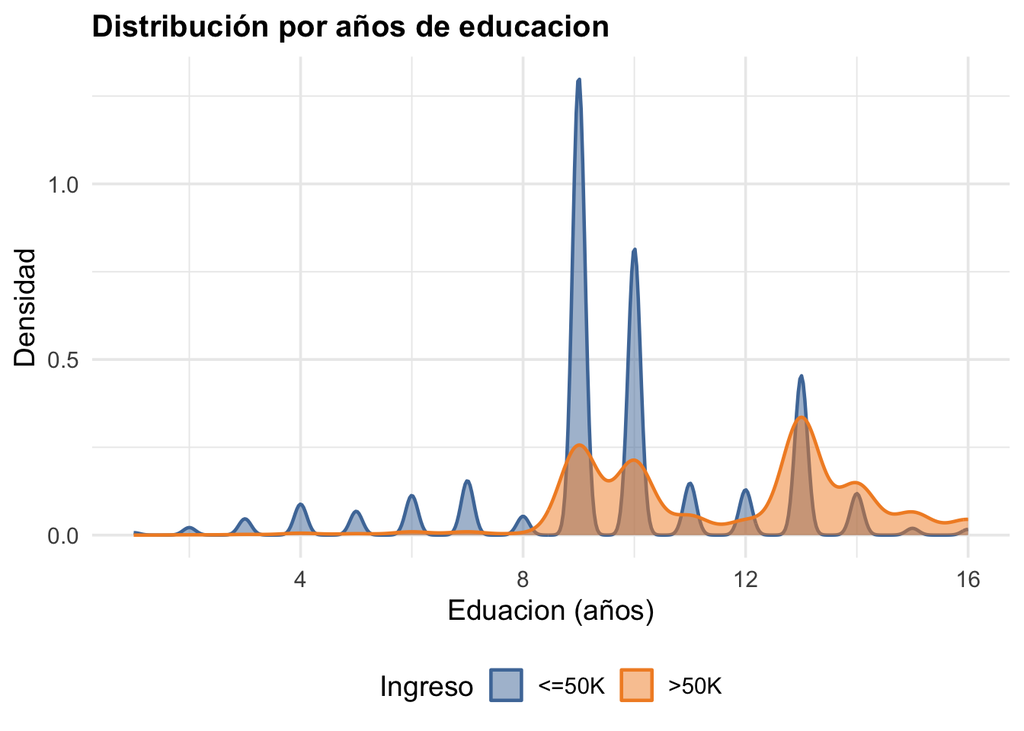

```r
#Education_num vs Income (Violin + Boxplot)
plot_edu_num <- base_mod |>
  ggplot(aes(x = education_num, fill = factor(income_bin), color = factor(income_bin))) +
  geom_density(alpha = 0.5, linewidth = 0.8) +
  scale_fill_manual(values = paleta_income, name = "Ingreso",
                    labels = c("0" = "<=50K", "1" = ">50K")) +
  scale_color_manual(values = paleta_income, name = "Ingreso",
                     labels = c("0" = "<=50K", "1" = ">50K")) +
  labs(
    title = "Distribución por años de educacion",
    x     = "Eduacion (años)",
    y     = "Densidad"
  ) +
  theme_minimal(base_size = 14) +
  theme(
    plot.title      = element_text(face = "bold", size = 15),
    legend.position = "bottom"
  )

print (plot_edu_num)
```

## ¿POR QUE TRANSFORMAR LAS VARIABLES? Y ¿POR QUE REALIZAR INTERACCIONES?:

A partir de las visualizaciones exploratorias, decidimos transformar las variables continuas en categorías binarias para facilitar la interpretación del modelo logístico.

Para la **edad**, se construyeron grupos asociados a distintas etapas del ciclo laboral (jóvenes, adultos jóvenes, adultos y mayores), debido a que los ingresos suelen variar según la experiencia acumulada y la trayectoria laboral. Entonces, resulta mas comodo analizar diferencias entre etapas de vida que asumir un efecto lineal.

Para **educación**, se modifico la variable en niveles educativos (educación baja, secundaria, terciaria incompleta, universitaria y posgrado). Esta transformación se debe a que se asume que distintos niveles educativos generan retornos salariales diferentes en el mercado de trabajo.

Por ultimo, las **horas trabajadas por semana** se agruparon en categorías (part-time, full-time estándar, jornada extendida y sobrecarga laboral). Esta decisión permite captar como los diferentes tipos de trabajo afectan los ingresos.

## DECISIONES DE TRANSFORMACION

Entonces, luego de ver como se distribuyen las variables hacemos algunas modificaciones para mejorar los modelos y su interpretacion:

```r
#Modificamos la educacion, transformandolo en variables binarias
base_mod <- base_mod %>%
  mutate(

    educ_baja = ifelse(education_num %in% c(1:8), 1,
                       ifelse(education_num %in% c(9:16), 0, NA)),

    educ_secundaria = ifelse(education_num %in% c(9,10), 1,
                             ifelse(education_num %in% c(c(1:8),11:16), 0, NA)),

    educ_terc_inc = ifelse(education_num %in% c(11,12), 1,
                           ifelse(education_num %in% c(c(1:10),13:16), 0, NA)),

    educ_universitaria = ifelse(education_num == 13, 1,
                                ifelse(education_num %in% c(1:12,14:16), 0, NA)),

    educ_posgrado = ifelse(education_num %in% c(14:16), 1,
                           ifelse(education_num %in% c(1:13), 0, NA))
  )
```

```r
#Modificamos la edad
base_mod <- base_mod %>%
  mutate(

    edad_joven = ifelse(age >= 17 & age <= 29, 1,
                        ifelse(age >= 30, 0, NA)),

    edad_adulto_joven = ifelse(age >= 30 & age <= 44, 1,
                               ifelse(age < 30 | age >= 45, 0, NA)),

    edad_adulto = ifelse(age >= 45 & age <= 59, 1,
                         ifelse(age < 45 | age >= 60, 0, NA)),

    edad_mayor = ifelse(age >= 60, 1,
                        ifelse(age < 60, 0, NA))
  )
```

```r
#Modificamos las horas
base_mod <- base_mod %>%
  mutate(

    horas_part_time = ifelse(hours_per_week < 35, 1,
                             ifelse(hours_per_week >= 35, 0, NA)),

    horas_full_time = ifelse(hours_per_week >= 35 &
                               hours_per_week <= 44, 1,
                             ifelse(hours_per_week < 35 |
                                      hours_per_week >= 45, 0, NA)),

    horas_extendido = ifelse(hours_per_week >= 45 &
                               hours_per_week <= 59, 1,
                             ifelse(hours_per_week < 45 |
                                      hours_per_week >= 60, 0, NA)),

    horas_sobrecarga = ifelse(hours_per_week >= 60, 1,
                              ifelse(hours_per_week < 60, 0, NA))
  )
```

## DECISION DE INTERACCION:

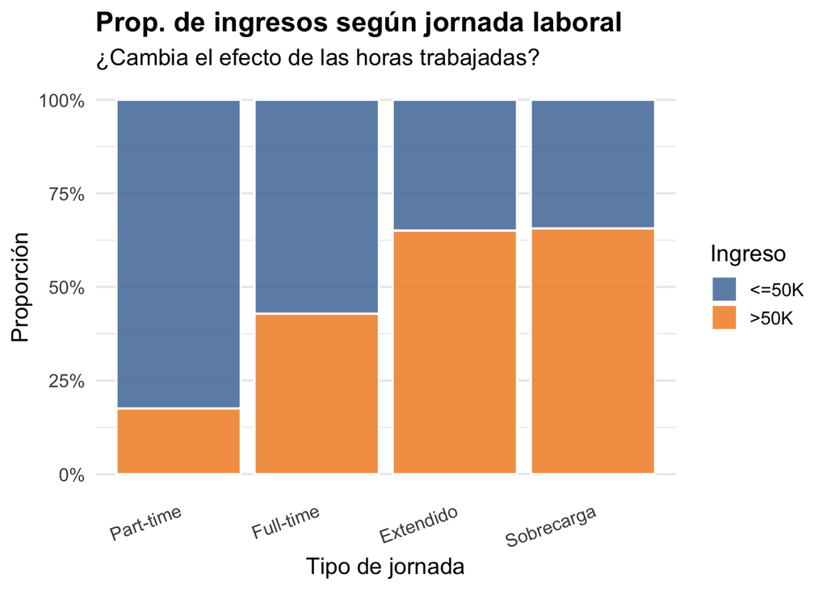

```r
# Creamos variable categórica de jornada laboral
graf <- base_mod |>
  mutate(
    jornada = case_when(
      hours_per_week < 35                          ~ "Part-time",
      hours_per_week >= 35 & hours_per_week <= 44  ~ "Full-time",
      hours_per_week >= 45 & hours_per_week <= 59  ~ "Extendido",
      hours_per_week >= 60                         ~ "Sobrecarga"
    ) |> factor(levels = c("Part-time", "Full-time",
                            "Extendido", "Sobrecarga"))
  )


p_barras <- graf |>
  ggplot(aes(x = jornada, fill = factor(income_bin))) +
  geom_bar(position = "fill", alpha = 0.85, color = "white") +

  scale_fill_manual(values = c("0" = "#4e79a7", "1" = "#f28e2b"),
                    name   = "Ingreso",
                    labels = c("0" = "<=50K", "1" = ">50K")) +
  scale_y_continuous(labels = label_percent()) +
  labs(
    title    = "Prop. de ingresos según jornada laboral",
    subtitle = "¿Cambia el efecto de las horas trabajadas?",
    x        = "Tipo de jornada",
    y        = "Proporción"
  ) +
  theme_minimal(base_size = 14) +
  theme(
    plot.title           = element_text(face = "bold"),
    axis.text.x          = element_text(angle = 20, hjust = 1),
    panel.grid.major.x   = element_blank()
  )

p_barras
```

Sin embargo, si diferenciamos entre hombre y mujer (por sexo) podemos enocntrar qu elos ingresos difieren entre si.

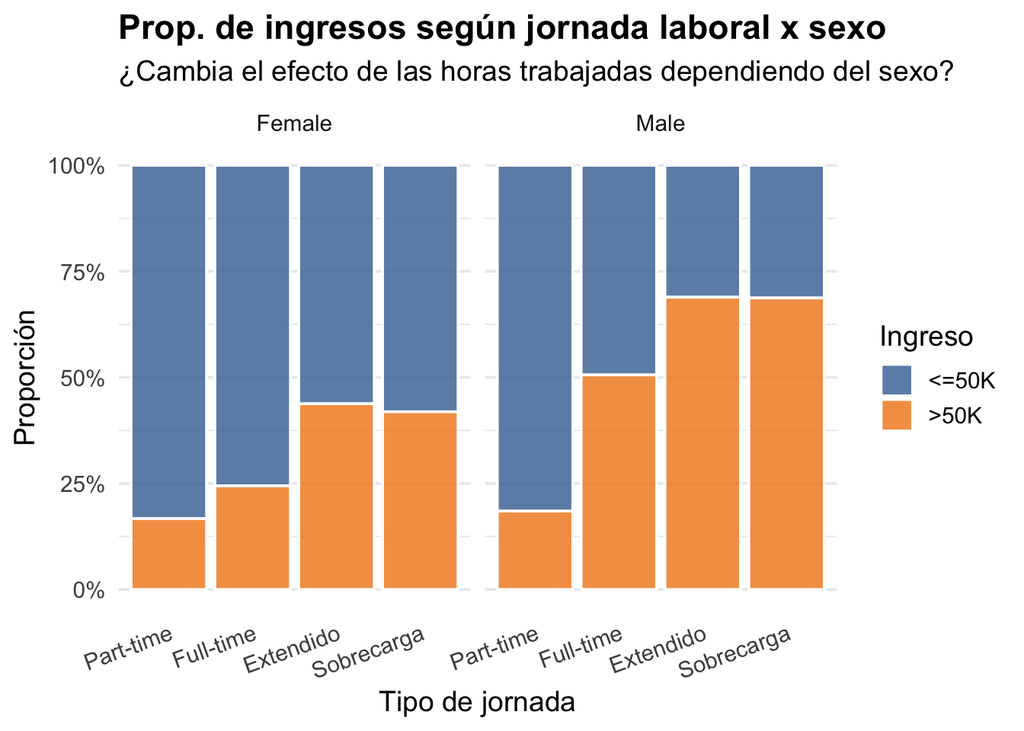

```r
# Grafico de barras para entender la distribución del ingreso
# segun las horas trabajadas, facetado por sexo.

p_interaccion_barras <- graf |>
  ggplot(aes(x = jornada, fill = factor(income_bin))) +
  geom_bar(position = "fill", alpha = 0.85, color = "white") +
  facet_wrap(~ sex) +
  scale_fill_manual(values = c("0" = "#4e79a7", "1" = "#f28e2b"),
                    name   = "Ingreso",
                    labels = c("0" = "<=50K", "1" = ">50K")) +
  scale_y_continuous(labels = label_percent()) +
  labs(
    title    = "Prop. de ingresos según jornada laboral x sexo",
    subtitle = "¿Cambia el efecto de las horas trabajadas dependiendo del sexo?",
    x        = "Tipo de jornada",
    y        = "Proporción"
  ) +
  theme_minimal(base_size = 14) +
  theme(
    plot.title           = element_text(face = "bold"),
    axis.text.x          = element_text(angle = 20, hjust = 1),
    panel.grid.major.x   = element_blank()
  )

p_interaccion_barras
```

Asi, el análisis muestra que la relación entre **horas trabajadas e ingresos altos** no es igual para hombres y mujeres. Aunque ambos grupos parten de niveles similares en jornadas *part-time*, a medida que aumentan las horas trabajadas la proporción de ingresos superiores a USD 50.000 crece mucho más entre los hombres que entre las mujeres. Esto indica que el efecto de las horas trabajadas varía según el sexo.

Entonces, una vez que observamos esto, decidimos incorporar la interacción entre **horas trabajadas por semana y sexo**, ya que el efecto de trabajar más horas no es igual para hombres y mujeres. En general, trabajar jornadas más largas suele estar más asociado a ingresos altos en los hombres, mientras que en las mujeres este efecto puede verse limitado por una mayor carga de trabajo doméstico y de cuidados no remunerados. Por eso, incluir esta interacción permite analizar si el impacto de las horas trabajadas sobre el ingreso cambia según el sexo del individuo.

## AJUSTE DE MODELOS:

Primero fijamos nuestras categorias de referencia antes de correr los modelos:

- Para la categoria **nivel de educacion** vamos a utilizar **educ_baja** la cual permite comparar cuánto aumenta la probabilidad de ingresos altos a medida que se asciende en el nivel educativo.
- Para la categoria **edad** vamos a utilizar **edad_joven** la cual sirve para evaluar cómo cambia el ingreso a lo largo del ciclo laboral.
- Para la categoria **horas trabajadas** vamos a utilizar **horas_part_time** la cual permite observar el efecto de trabajar jornadas más extensas respecto a quienes trabajan pocas horas.
- Para la categoria de **estado civil** vamos a utilizar **married** ya que es la categoría más numerosa y esta asociada a mayores ingresos.

## MODELO 1:

```r
modelo_base <- glm(
  income_bin ~
    edad_adulto_joven +
    edad_adulto +
    edad_mayor +
    educ_secundaria +
    educ_terc_inc +
    educ_universitaria +
    educ_posgrado +
    horas_full_time +
    horas_extendido +
    horas_sobrecarga +
    never_married +
    div_sep +
    widowed_other +
    sex,
  family = binomial(link = "logit"),
  data = base_mod
)

summary (modelo_base)
```

```
Call:
glm(formula = income_bin ~ edad_adulto_joven + edad_adulto +
    edad_mayor + educ_secundaria + educ_terc_inc + educ_universitaria +
    educ_posgrado + horas_full_time + horas_extendido + horas_sobrecarga +
    never_married + div_sep + widowed_other + sex, family = binomial(link = "logit"),
    data = base_mod)

Coefficients:
                   Estimate Std. Error z value Pr(>|z|)
(Intercept)        -3.18314    0.13439 -23.685  < 2e-16 ***
edad_adulto_joven   1.18131    0.06730  17.552  < 2e-16 ***
edad_adulto         1.52625    0.07218  21.144  < 2e-16 ***
edad_mayor          1.27043    0.10014  12.687  < 2e-16 ***
educ_secundaria     1.25296    0.08591  14.585  < 2e-16 ***
educ_terc_inc       1.79717    0.10817  16.614  < 2e-16 ***
educ_universitaria  2.69364    0.09624  27.988  < 2e-16 ***
educ_posgrado       3.31986    0.10880  30.514  < 2e-16 ***
horas_full_time     0.85640    0.08590   9.969  < 2e-16 ***
horas_extendido     1.46839    0.09273  15.836  < 2e-16 ***
horas_sobrecarga    1.36805    0.10612  12.891  < 2e-16 ***
never_married      -2.46605    0.06769 -36.430  < 2e-16 ***
div_sep            -2.14552    0.06717 -31.944  < 2e-16 ***
widowed_other      -1.89636    0.12968 -14.623  < 2e-16 ***
sexMale             0.19084    0.05580   3.420 0.000626 ***
---
Signif. codes:  0 '***' 0.001 '**' 0.01 '*' 0.05 '.' 0.1 ' ' 1

(Dispersion parameter for binomial family taken to be 1)

    Null deviance: 21821  on 15765  degrees of freedom
Residual deviance: 13845  on 15751  degrees of freedom
AIC: 13875

Number of Fisher Scoring iterations: 5
```

## MODELO 2:

```r
modelo2 <- glm(
  income_bin ~
    edad_adulto_joven +
    edad_adulto +
    edad_mayor +
    educ_secundaria +
    educ_terc_inc +
    educ_universitaria +
    educ_posgrado +
    horas_full_time +
    horas_extendido +
    horas_sobrecarga +
    never_married +
    div_sep +
    widowed_other +
    sex +
    sex*horas_full_time +
    sex*horas_extendido +
    sex*horas_sobrecarga,
  family = binomial(link = "logit"),
  data = base_mod
)

summary (modelo2)
```

```
Call:
glm(formula = income_bin ~ edad_adulto_joven + edad_adulto +
    edad_mayor + educ_secundaria + educ_terc_inc + educ_universitaria +
    educ_posgrado + horas_full_time + horas_extendido + horas_sobrecarga +
    never_married + div_sep + widowed_other + sex + sex * horas_full_time +
    sex * horas_extendido + sex * horas_sobrecarga, family = binomial(link = "logit"),
    data = base_mod)

Coefficients:
                         Estimate Std. Error z value Pr(>|z|)
(Intercept)              -2.74543    0.14975 -18.334  < 2e-16 ***
edad_adulto_joven         1.17988    0.06735  17.518  < 2e-16 ***
edad_adulto               1.53062    0.07228  21.175  < 2e-16 ***
edad_mayor                1.32263    0.10090  13.108  < 2e-16 ***
educ_secundaria           1.26137    0.08614  14.643  < 2e-16 ***
educ_terc_inc             1.80795    0.10849  16.665  < 2e-16 ***
educ_universitaria        2.70543    0.09646  28.046  < 2e-16 ***
educ_posgrado             3.34557    0.10917  30.645  < 2e-16 ***
horas_full_time           0.29114    0.12349   2.358  0.01839 *
horas_extendido           0.97964    0.14925   6.564 5.25e-11 ***
horas_sobrecarga          0.97656    0.21349   4.574 4.78e-06 ***
never_married            -2.45350    0.06790 -36.133  < 2e-16 ***
div_sep                  -2.13053    0.06720 -31.706  < 2e-16 ***
widowed_other            -1.92823    0.12931 -14.911  < 2e-16 ***
sexMale                  -0.69291    0.15852  -4.371 1.24e-05 ***
horas_full_time:sexMale   1.03106    0.16992   6.068 1.30e-09 ***
horas_extendido:sexMale   0.92437    0.19226   4.808 1.52e-06 ***
horas_sobrecarga:sexMale  0.81026    0.25159   3.221  0.00128 **
---
Signif. codes:  0 '***' 0.001 '**' 0.01 '*' 0.05 '.' 0.1 ' ' 1

(Dispersion parameter for binomial family taken to be 1)

    Null deviance: 21821  on 15765  degrees of freedom
Residual deviance: 13808  on 15748  degrees of freedom
AIC: 13844

Number of Fisher Scoring iterations: 5
```

### INTERPRETACIONES DE RESULTADOS:

**MODELO BASE:** asume que el efecto de trabajar más horas es idéntico para hombres y mujeres. Bajo esta perspectiva, el género influye de manera constante sobre la probabilidad de obtener ingresos superiores a USD 50.000, mientras que las horas trabajadas tienen el mismo impacto independientemente del sexo.

Los resultados indican que la educación es el principal determinante de los ingresos altos. A medida que aumenta el nivel educativo, también crecen significativamente las probabilidades de pertenecer al grupo de mayores ingresos. Del mismo modo, los adultos presentan mayores probabilidades de alcanzar ingresos elevados que los jóvenes, y las personas casadas muestran una situación más favorable que quienes nunca se casaron, están divorciados o son viudos.

**MODELO 2 (INTERACTIVO):** introduce una interacción entre sexo y horas trabajadas para evaluar si el rendimiento económico asociado a una mayor dedicación laboral varía según el género. Los coeficientes de interacción son positivos y estadísticamente significativos, lo que sugiere que el beneficio de trabajar más horas es más pronunciado entre los hombres.

Una diferencia relevante entre ambos modelos es que, mientras el Modelo 1 muestra una ventaja promedio para los hombres en términos de ingresos, el Modelo 2 revela que dicha ventaja depende de la cantidad de horas trabajadas. Al incorporar la interacción, el efecto principal de ser hombre se vuelve negativo, pero este resultado se compensa con los efectos positivos de las jornadas laborales más extensas.

Entonces, el Modelo 2 ofrece una visión más detallada de la relación entre género e ingresos. Los resultados sugieren que las diferencias entre hombres y mujeres no son constantes, sino que dependen de la intensidad de trabajo. En particular, los hombres parecen recibir mayores retornos económicos cuando trabajan jornadas completas o prolongadas, lo que evidencia que las recompensas asociadas al tiempo dedicado al trabajo no son iguales para ambos sexos.

Sin embargo, para facilitar la interpretación sustantiva de los coeficientes del modelo logístico interactivo, se calcularon los Efectos Marginales Promedio (AME).

```r
# Efectos Marginales Promedio
efectos_marginales <- avg_slopes(
  modelo2,
  variables = c(
    "edad_adulto_joven",
    "edad_adulto",
    "edad_mayor",
    "educ_secundaria",
    "educ_terc_inc",
    "educ_universitaria",
    "educ_posgrado",
    "horas_full_time",
    "horas_extendido",
    "horas_sobrecarga",
    "never_married",
    "div_sep",
    "widowed_other",
    "sex"
  ),
  slope = "dydx"
)

# Tabla estética
efectos_marginales |>

  select(
    term,
    contrast,
    estimate,
    conf.low,
    conf.high,
    p.value
  ) |>

  mutate(

    estimate_pct = paste0(round(estimate*100,2), "%"),

    interpretacion = case_when(
      estimate > 0 & p.value < 0.05 ~ "Aumenta prob. (Sig.)",
      estimate < 0 & p.value < 0.05 ~ "Reduce prob. (Sig.)",
      TRUE ~ "No significativo"
    )

  ) |>

  select(
    term,
    contrast,
    estimate_pct,
    conf.low,
    conf.high,
    p.value,
    interpretacion
  ) |>

  rename(
    `Predictor` = term,
    `Contraste` = contrast,
    `Efecto (Prob.)` = estimate_pct,
    `IC Inferior` = conf.low,
    `IC Superior` = conf.high,
    `Valor p` = p.value,
    `Interpretación` = interpretacion
  ) |>

  knitr::kable(
    digits = 4,
    caption = "Efectos Marginales Promedio (AME) - Modelo 2"
  ) |>

  kable_styling(
    bootstrap_options = c(
      "striped",
      "hover",
      "condensed",
      "responsive"
    ),
    full_width = FALSE,
    position = "center"
  ) |>

  row_spec(
    row = which(efectos_marginales$p.value < 0.05),
    bold = TRUE,
    color = "black",
    background = "#e6f2ff"
  )
```

Efectos Marginales Promedio (AME) - Modelo 2

| Predictor | Contraste | Efecto (Prob.) | IC Inferior | IC Superior | Valor p | Interpretación |
| --- | --- | --- | --- | --- | --- | --- |
| div_sep | 1 - 0 | -31.14% | -0.3279 | -0.2949 | 0e+00 | Reduce prob. (Sig.) |
| edad_adulto | 1 - 0 | 21.9% | 0.1999 | 0.2380 | 0e+00 | Aumenta prob. (Sig.) |
| edad_adulto_joven | 1 - 0 | 16.64% | 0.1488 | 0.1841 | 0e+00 | Aumenta prob. (Sig.) |
| edad_mayor | 1 - 0 | 17.7% | 0.1529 | 0.2011 | 0e+00 | Aumenta prob. (Sig.) |
| educ_posgrado | 1 - 0 | 42.78% | 0.4082 | 0.4475 | 0e+00 | Aumenta prob. (Sig.) |
| educ_secundaria | 1 - 0 | 16.52% | 0.1461 | 0.1843 | 0e+00 | Aumenta prob. (Sig.) |
| educ_terc_inc | 1 - 0 | 23.6% | 0.2120 | 0.2601 | 0e+00 | Aumenta prob. (Sig.) |
| educ_universitaria | 1 - 0 | 36.27% | 0.3423 | 0.3831 | 0e+00 | Aumenta prob. (Sig.) |
| horas_extendido | 1 - 0 | 22.97% | 0.2054 | 0.2539 | 0e+00 | Aumenta prob. (Sig.) |
| horas_full_time | 1 - 0 | 14.24% | 0.1204 | 0.1644 | 0e+00 | Aumenta prob. (Sig.) |
| horas_sobrecarga | 1 - 0 | 20.68% | 0.1801 | 0.2335 | 0e+00 | Aumenta prob. (Sig.) |
| never_married | 1 - 0 | -37.17% | -0.3884 | -0.3550 | 0e+00 | Reduce prob. (Sig.) |
| sex | Male - Female | 3.11% | 0.0147 | 0.0476 | 2e-04 | Aumenta prob. (Sig.) |
| widowed_other | 1 - 0 | -26.67% | -0.2970 | -0.2364 | 0e+00 | Reduce prob. (Sig.) |

## GRAFICO DE BOSQUE PARA VISUALIZAR LOS RESULTADOS:

[figure not shown]

```r
df_plot_or <- broom::tidy(modelo2) |>
  filter(!term %in% c("(Intercept)", "educ_posgrado", "never_married")) |>
  mutate(
    lo_80 = estimate - qnorm(0.90)  * std.error,
    hi_80 = estimate + qnorm(0.90)  * std.error,
    lo_95 = estimate - qnorm(0.975) * std.error,
    hi_95 = estimate + qnorm(0.975) * std.error,
    lo_99 = estimate - qnorm(0.995) * std.error,
    hi_99 = estimate + qnorm(0.995) * std.error,
    across(c(estimate, starts_with("lo_"), starts_with("hi_")), exp),
    term_clean = case_match(
      term,
      "edad_adulto_joven"        ~ "Edad: Adulto joven",
      "edad_adulto"              ~ "Edad: Adulto",
      "edad_mayor"               ~ "Edad: Mayor",
      "educ_secundaria"          ~ "Educación secundaria",
      "educ_terc_inc"            ~ "Educación terciaria incompleta",
      "educ_universitaria"       ~ "Educación universitaria",
      "horas_full_time"          ~ "Horas: Full-time",
      "horas_extendido"          ~ "Horas: Jornada extendida",
      "horas_sobrecarga"         ~ "Horas: Sobrecarga",
      "div_sep"                  ~ "Divorciado/Separado",
      "widowed_other"            ~ "Viudo/Otro",
      "sexMale"                  ~ "Hombre",
      "horas_full_time:sexMale"  ~ "Interacción: Hombre × Full-time",
      "horas_extendido:sexMale"  ~ "Interacción: Hombre × Extendido",
      "horas_sobrecarga:sexMale" ~ "Interacción: Hombre × Sobrecarga",
      .default = term
    ),
    sig = p.value < 0.05
  )

ggplot(df_plot_or, aes(y = reorder(term_clean, estimate), x = estimate)) +
  geom_vline(xintercept = 1, linetype = "dashed", color = "gray40", linewidth = 0.8) +
  geom_linerange(aes(xmin = lo_99, xmax = hi_99), color = "#74ADD1", linewidth = 1) +
  geom_linerange(aes(xmin = lo_95, xmax = hi_95), color = "#4575B4", linewidth = 2.5) +
  geom_linerange(aes(xmin = lo_80, xmax = hi_80), color = "#313695", linewidth = 5) +
  geom_point(aes(color = sig), size = 3.5) +
  scale_color_manual(values = c("TRUE" = "#D73027", "FALSE" = "gray50"), guide = "none") +
 scale_x_log10(
  breaks = c(0.2, 0.5, 1, 2, 5, 10),
  labels = c("0.2", "0.5", "1", "2", "5", "10"),
  limits = c(0.15, 11)

  ) +
  labs(
    title    = "Odds Ratios del Modelo Logístico Interactivo",
    subtitle = "Intervalos de confianza: 80% (gruesa), 95% (media), 99% (fina)\nPuntos rojos = significativo (p<0.05), grises = no significativo",
    x        = "Odds Ratio (Escala Logarítmica)",
    y        = NULL,
    caption  = "Línea punteada: OR = 1 (ausencia de efecto).\nExcluidos por escala: educ_posgrado (OR ≈ 20) y never_married (OR ≈ 0.07)."
  ) +
  theme_minimal(base_size = 13) +
  theme(
    plot.title         = element_text(face = "bold", size = 15),
    plot.subtitle      = element_text(size = 11, color = "gray30"),
    panel.grid.minor   = element_blank(),
    panel.grid.major.y = element_blank(),
    axis.text.y        = element_text(face = "bold", size = 11),
    axis.text.x        = element_text(size = 10)
  )
```

El gráfico de Odds Ratios confirma los resultados obtenidos en la tabla del Modelo 2 y permite identificar con mayor claridad cuáles son los factores más importantes para explicar los ingresos altos.

A su vez, los grupos de edad adulto joven, adulto y mayor presentan mayores probabilidades de alcanzar ingresos elevados en comparación con la categoría de referencia, lo que sugiere que la experiencia laboral acumulada juega un papel importante.

Las jornadas laborales full-time, extendidas y de sobrecarga también muestran efectos positivos y significativos, evidenciando que trabajar más horas está asociado con mayores ingresos.

Por lo tanto, el gráfico coincide con los resultados observados en la tabla y refuerza la idea de que la educación, la edad, las horas trabajadas y la interacción entre género y dedicación laboral son los principales factores asociados a la obtención de ingresos elevados.

## COMPARANDO MODELOS:

```r
bind_rows(
  broom::glance(modelo_base) |> mutate(Modelo = "1. Sin Interacción"),
  broom::glance(modelo2) |> mutate(Modelo = "2. Con Interacción")
) |>
  mutate(pseudo_r2 = 1 - (deviance / null.deviance)) |>
  select(Modelo, null.deviance, deviance, pseudo_r2, AIC, nobs) |>
  rename(
    `Deviance Nula`        = null.deviance,
    `Deviance Residual`    = deviance,
    `Pseudo-R² (McFadden)` = pseudo_r2,
    `Observaciones`        = nobs
  ) |>
  knitr::kable(
    digits  = c(0, 1, 1, 3, 1, 0),
    caption = "Métricas de Ajuste Global"
  ) |>
  kable_styling(
    bootstrap_options = c("striped", "hover", "condensed", "responsive"),
    full_width = FALSE,
    position   = "center"
  ) |>
  row_spec(
    row        = 2,
    bold       = TRUE,
    color      = "black",
    background = "#e6f2ff"
  )
```

Métricas de Ajuste Global

| Modelo | Deviance Nula | Deviance Residual | Pseudo-R² (McFadden) | AIC | Observaciones |
| --- | --- | --- | --- | --- | --- |
| 1. Sin Interacción | 21820.6 | 13845.1 | 0.366 | 13875.1 | 15766 |
| 2. Con Interacción | 21820.6 | 13808.2 | 0.367 | 13844.2 | 15766 |

## CONCLUSIONES:

En conclusion, si bien ambos modelos presentan un buen desempeño, el **Modelo 2** muestra resultados superiores. En particular, registra una menor Deviance Residual y un AIC más bajo, lo que indica un mejor ajuste a los datos sin aumentar excesivamente la complejidad del modelo. Además, el Pseudo-R² de McFadden también es levemente mayor. En conjunto, estos resultados sugieren que incorporar la interacción entre sexo y horas trabajadas aporta información relevante para explicar los ingresos, por lo que el Modelo 2 resulta la mejor opcion para el análisis.